# Working with Mutation Data

Kate Guion

2022-02-22

# 1 Setup

## 1.1 Deliverables

As with the clinical tutorial, please copy all these code blocks into a new Rscript file called `week7_maf_analysis.R` in your `week7_maf` folder. This file will be checked off as homework.

## 1.2 MAF Package Setup

We need to install the packages we will be using (if we haven’t yet) already, and load in the other packages we want to use. In this case, we just need to download the `maftools` package from Bioconductor.

**This package is the reason why, if you have an Apple Silicon Mac, we asked you to download the x86-64 binary of R. `maftools` doesn’t work on the ARM version of R (as of the end of 2021). If you have the ARM version of R, you will likely see a bunch of errors (regarding needing to compile packages) when you try to install `maftools`.** If you get these errors, you will have to install the Intel (x86-64) version of R from [here](https://cran.r-project.org/bin/macosx/), and download RSwitch [here](https://rud.is/rswitch/) to switch to the R version.

**Exercise 1.1** As before, download the `maftools` package using `BiocManager::install()`. We’ll also use the `TCGAbiolinks` package.

1. Install the `maftools` package and load it. Also load in `TCGAbiolinks`.
2. Set your working directory to your `analysis_data` folder in your GitHub repository.

```r
# install maftools, load packages, then
# set our working directory
```

**Exercise 1.2** First, we need to get the clinical data that we generated in week4; it was named `"coad_clinical_data.csv"` in the tutorial. We need it to add to the MAF file. If you can’t find your csv file, ask for help. Finally, rename the patient barcode column to allow `maftools` to merge it with the mutation data.

```r
# SET YOUR WORKING DIRECTORY TO YOUR analysis_data FOLDER
setwd(...)  # fill in here

# replace the path!
# fread is a way to read in a data frame, but it's much faster than the built-in read.csv()
# by default, it reads it in as a slightly different data type than a data frame, so we set the data.table flag to false
clinic <- data.table::fread("/Users/kateguion/Documents/qbiostudentgroup/analysis_data/...",
                            data.table = F)

# rename the patient barcode to make it work with maftools
colnames(clinic)[ colnames(clinic) == "bcr_patient_barcode" ] <- "Tumor_Sample_Barcode"
```

**Exercise 1.3** *Check your understanding*: regarding the last line of code that renames the `bcr_patient_barcode` column, answer the following:

1. How long is `colnames(clinic)`?
2. How long is `colnames(clinic) == "bcr_patient_barcode`? What kind of information does `colnames(clinic) == "bcr_patient_barcode` contain (i.e. what data type is it)?
3. How many `TRUE`s are there in `colnames(clinic) == "bcr_patient_barcode`?

**Exercise 1.4** Next, we need to download the MAF data via `TCGAbiolinks.` To query our data, we use the `GDCquery_Maf()` function. We want the `"COAD"` tumors, and we want the data processed by the `"mutect2"` pipeline. Fill in the argument below! (Make sure that you pass the argument as strings!)

Then, we access the data using the `read.maf()` funciton. The maf file we want to read is the `mutation_query` object, and the clinicalData is our `clinic` data frame.

```r
# fill in!!
mutation_query <- GDCquery_Maf(tumor = ...,
                               pipeline = ...,
                               save.csv = TRUE)

maf_object <- read.maf(maf = ...,
                       clinicalData = ...,
                       isTCGA = TRUE)
```

Notice we have saved the MAF file as a csv, as seen in the argument `save.csv = TRUE`. We did this so we don’t have to re-query for the MAF file every time we want to use it, e.g. after you restart R. The next exercise shows how this technique can save time.

**Exercise 1.5 (Load in mutation data as a csv)** To demonstrate how to read the data back into a clean environment *without* using TCGAbiolinks, we’ll take the following steps:

1. Simulate restarting R by clearing your environment: press the broom button on the top right panel under “Environment”.
2. Then, using `getwd()`, `setwd()`, and `list.files()`, navigate to your `GDCdata/` folder in `analysis_data` and find the mutation file csv The file name will be named something like `TCGA.COAD.mutect.03652df4-6090-4f5a-a2ff-ee28a37f9301.DR-10.0.somatic.maf.csv`
3. Read this file into a dataframe called `maf_dataframe` using `data.table::fread()`. (Refer to the `fread()` part of the previous example where we read in the clinical data – be sure to read in the *mutation* data, not clinical!)
4. Then, since we cleaned our working directory, we also need to read in our clinical data into `clinic`. (Again, refer to the previous `data.table::fread()` example.)
5. Finally, we use the `read.maf()` function to reconstruct our MAF object.

```r
# 1. clear your environment either using the following code or by clicking the broom.

# 2. Locate the appropriate csv file

# 3. Use fread to read in the *mutation* data you just downloaded (refer to the fread syntax from the previous example)
maf_dataframe = ...

# 4. Read in your clinic data frame
# you also need to rename the bcr_patient_barcode again
# refer to the previous example!

# re-create the maf_object as before
maf_object <- read.maf(...)
```

# 2 Exploring the MAF Object

**Exercise 2.1** Let’s examine the `maf_object`. These are several standard commands used in R to get summaries of objects. Run the following to see what is contained in the `maf_object`:

1. Just type the name of the MAF object and run that line alone. This will call the default `print()` function on it.
2. Call `str()` on it. Do you see all the different objects (data frames, in this case) contained in the MAF object? (They are represented by `@`, which is the R way to access data within an object. This is more or less equivalent to the `.` in other languages such as C++ and Python).
3. Access the `data` and `clinical.data` data frames stored in MAF object (use the `@` operator). Use the previous methods to examine these two data frames. Which column is shared between these two? Does this make sense?

```r
# explore here!
```

# 3 Performing Analysis

## 3.1 Oncoplot Basics

Now, we are going to make our first figure using the `oncoplot()` function. The horizontal axis of the oncoplot represents each individual patient, and the vertical axis contains the $n$ genes mutated in the most patients. The different colors represent the different types of mutations.

**Exercise 3.1** Generate the oncoplot by filling in the `maf` argument. Then, fill in the `top` argument with various integer arguments (e.g. 5, 10, 20, etc.) to see the genes that are mutated in the most patients. Finally, save the oncoplot **into your week7 folder** using the `ggsave()` function (be sure to rename the filename!).

```r
# play with the number of genes with the "top" argument
oncoplot(maf = ...,
         top = ...)

ggsave("PATH/TO/week7_maf/filename.png")
```

**Exercise 3.2** Choose one of the most mutated genes in your oncoplot and Google it. What is the function of this gene? Remember, at a basic level, cancer is uncontrolled cell growth. Does your gene relate to cell growth and proliferation (division)? If so, how?

## 3.2 Comparing Different Groups of Patients

What if we want to compare two different groups of patients? Here, we will compare young and old patients (where again, young patients are under 50, and old patients are over 50). First, we need to create two different MAF objects using the `subsetMaf()` function. The `subsetMaf(maf, tsb)` function needs two arguments in this case: `maf` is the original MAF object, and `tsb` is a vector of patient IDs (barcodes) to select.

**Exercise 3.3** To split the `maf` object, follow these steps:

1. Write the `clinical.data` data frame from your `maf_object` into the `clinic` variable, using the `@` accession operator. (This is just to simplify the syntax slightly and to make sure your `clinic` dataframe is fully up to date).
2. In a new variable called `young_patient_ids`, store the patient IDs that correspond to the young patients (all the information should be contained in the `clinic` data frame – in all likelihood, you have already created the `age_category` column in week4). The patient ids are stored in the `"Tumor_Sample_Barcode"` column.
3. Call `subsetMaf()` to create a new MAF object, `young_maf`, containing only the young patients.
4. Finally, repeat steps 2-3 to create `old_maf`. Try to construct it in one line if you can think of a way to do so!

```r
# 1. Write to clinic again
clinic = ...

# 2. Create the young_patients_ids vector
young_patients_ids = ...

# 3. Create another
young_maf = subsetMaf(maf = ...,
                       tsb = ...)

# 4. Repeat steps 2-3 to create an old_maf! Can you do it in one line?
```

**Exercise 3.4** Use `coOncoplot()` to draw two oncoplots side by side, comparing young vs. old patients. `m1` is the first MAF object to plot, and `m2` is the second. Be sure to provide descriptive names in the `m1Name` and `m2Name` arguments! Again, save the plot using the `ggsave()` function.

```r
coOncoplot(m1 = ...,
           m2 = ...,
           m1Name = ...,
           m2Name = ...)

ggsave("PATH/TO/week7_maf/filename.png")
```

**Exercise 3.5** Notice that there may be very few young patients, making the young oncoplot is difficult to see. However, look at the percent of patients mutated (the percentages on the left and right sides). What do you notice? Are all the genes more mutated in one group? Or is there a mix? Is it what you expected?

## 3.3 Lollipop Plots

Lollipop plots display the location of each mutation along the gene’s DNA sequence. To do so, we use the `lollipopPlot()` function from `maftools`. For example, here’s a lollipop plot of the protein HAND2, which has a fairly simple representation.[^1]. The long gray rectangle represents the amino acid sequence, and any annotations/special protein sequences are overlaid in a colored rectangle (for example, in our case, HLH is a common DNA-binding protein motif). Mutations are annotated by the ball-and-stick, which looks like a lollipop, hence the name; the color represents the type of mutation. These mutations can occur in any of the amino acids in the gene! The vertical axis shows the number of mutated samples, although the label sometimes gets cut off if there’s many mutations.

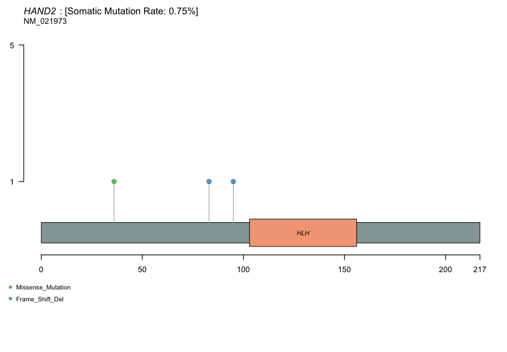

**Exercise 3.6** Fill in the function with the gene you looked up earlier in Exercise 3.2. Be sure to write the gene name as a string (i.e. surround it with quotation marks). Finally, save the plot!

```r
# pick a gene to look at!
lollipopPlot(maf_object, gene = "pick a gene here!")

ggsave("PATH/TO/week7_maf/filename.png")
```

**Exercise 3.7** As with `coOncoplot()`, we can also compare two groups using `lollipopPlot2()`. Fill in the code below!

Then, interpret your plot. For example, answer the following questions:

- Does it look like the gene is more commonly mutated in young or old patients?
- Are there more mutations in a specific region of the protein? Why might that be?
- What kinds of mutations are the most common?
- Are there any other interesting observations?

```r
# pick a gene to look at!
lollipopPlot2(m1 = ...,
              m2 = ...,
              m1_name = ...,
              m2_name = ...,
              gene = "pick a gene!")

ggsave("PATH/TO/week7_maf/filename.png")
```

If you are interested in other figures with this MAF file, work through [this tutorial](https://www.bioconductor.org/packages/devel/bioc/vignettes/maftools/inst/doc/maftools.html#7_Visualization).

## 3.4 Statistical Analyses

The final analysis to perform with the MAF file is co-mutations. More specifically, we are interested in identifying mutations that seem to occur together.

The primary way to perform this statistical analysis is the Fisher’s Exact test. (This is NOT meant to replace your statistical course, so only a basic understanding is required. For more information, Google, YouTube, and stats textbooks are all good resources. For further reference, take a look at [these slides](http://www.biostat.jhsph.edu/~iruczins/teaching/140.652/supp21.pdf)).

*Remark*. The Fisher’s Exact Test can be computationally expensive because it requires computing factorials. These grow very quickly in size (for example, if you have 500 samples, you might have to calculate $500! \approx 1.2\times 10^{1134}$, which is a giant number that ordinary computers can’t handle. For example, if you type `factorial(500)` in R, you get `Inf`, so you won’t be able to calculate a p-value). In the case that you have enough samples where you get an error with Fisher’s Exact Test, you can use a chi-squared approximation, which means you would used the `chisq.test()` function instead of `fisher.test()`.

At the base of a Fisher’s Exact test is a “contingency table” (typically a 2x2 table). The table below is a simple example of a contingency table.

|  | Mutation in Gene B | No Mutation in Gene B | Sum |
| --- | --- | --- | --- |
| **Mutation in Gene A** | 15 | 45 | 60 |
| **No Mutation in Gene A** | 30 | 10 | 40 |
| **Sum** | 45 | 55 | 100 |

To read this table, I could say, “There are 15 samples that have both a mutation in gene A and gene B”. I could also say, “15/60, or 25% of samples with a mutation in gene A also have a mutation in gene B”.

**Exercise 3.8** Interpret another cell of the table as in the previous paragraph.

The Fisher’s Exact test calculates the exact probability that the proportions in the table will be observed, the two variables are independent, by testing how “extreme” your table is. Another way to think about it is in the context of *independence.* In this example, Fisher’s Exact test is testing whether your variables (mutation in gene A, mutation in gene B) are independent of each other. That is, if the presence of a mutation in gene A and gene B are *independent*, knowing that you have a mutation in gene A does not gives you any information about having a mutation in gene B.

In statistical terms, the “null hypothesis” is that two variables are INDEPENDENT.

The p-value is the probability that, under the null hypothesis, that you see a result as extreme as the one you observe. A low p-value, then, suggests that it is unlikely that the null hypothesis is correct. In the Fisher’s Exact Test, this low p-value means that the table is fairly “extreme” or that the variables are NOT independent. In the context of the mutation data, the low p-value indicates that the two genes appear to be related in their mutation status (that is, having a mutation in gene A indicates that you are either much more or much less likely to have a mutation gene B).

**Exercise 3.9** *Check your understanding*. Answer the following questions!

1. Fill out the values for $b,c,d,e,f$ from the table below. (Hint: solve for $d$ last).
2. Does it appear that mutations in gene A and in gene B are independent? Why or why not? Don’t compute a p-value to answer this question. (Hint: look at the table you just filled out. Does it look like that knowing you have a mutation in gene A affect the chance that you have a mutation in gene B?)

```
b =
c =
d =
e =
f =
```

|  | Mutation in Gene B | No Mutation in Gene B | Sum |
| --- | --- | --- | --- |
| **Mutation in Gene A** | 6 | $b$ | 13 |
| **No Mutation in Gene A** | $c$ | $d$ | $e$ |
| **Sum** | 8 | $f$ | 50 |

Now let’s get started!

**Exercise 3.10** Let’s call geneA `"TP53"` and geneB `"KRAS"`. First, let’s subset the `maf_object` on genes, rather than patient ids. Call the `subsetMaf()` function, but rather than using the `tsb` argument, use the `genes` argument.

```r
# geneA is TP53
geneA_maf <- subsetMaf(maf = ...,
                       genes = ...)

# geneB is KRAS
geneB_maf <- subsetMaf(maf = ...,
                       genes = ...)
```

**Exercise 3.11** Examine `geneA_maf` and `geneB_maf`. Then answer the following questions:

- What did `subsetMaf()` do?
- Does each sample only have one mutation in geneA? How can you determine this? (Hint: Consider the `data` data frame contained in the original `maf_object`).
- Is the number of samples in each `data` section the same as the `clinical.data` section? Why or why not?

```r
# Examine here!
```

As you may have guessed, this analysis will be looking at the PRESENCE of a mutation, rather than the NUMBER of mutations in a sample.

Now, we need to start filling in that contingency table. Let’s start with the number of samples with a mutation in both `geneA` and `geneB`. The `intersect()` function identifies items that are in both lists. (This corresponds to the top-left cell in the contingency table).

**Exercise 3.12** To construct our contingency table, we need to find the number of patients with mutations in both `geneA` and `geneB.` Follow these steps to get started on the upper-left cell:

1. Identify which patients have a mutation in `geneA`, then repeat it with `geneB`. The information is stored in the `Tumor_Sample_Barcode` column of the two MAF objects that you just generated.
2. Check the number of patients with mutations in these genes using the `length()` function. *Check your understanding*: which portion of the contingency table do these numbers correspond to?
3. Identify the patients that a mutation in both using the `intersect()` function, and store these barcodes in `mut_bc_geneAB`. Then get the number of patients with a mutation in both A and B.

```r
# 1. Access the barcodes of the patients with mutations in genes A and B
# bc stands for barcode
mut_bc_geneA = ...
mut_bc_geneB = ...

# 2. Get the lengths of these two vectors
num_mut_geneA = ...
num_mut_geneB = ...

# 3. Fill in the intersect here! Then get the nubmer of patients
mut_bc_geneAB = intersect(...)
num_mut_geneAB = ...
```

**Exercise 3.13** Now, determine the number of patients with one mutation and not the other. (These correspond to the top-right and bottom-left cells in the contingency table.)

Hint: draw out the contingency table. We know the number of patients with a mutation in geneA, the number of patients in geneB, and the number with mutations in both geneA and geneB. We can do a little math to find out the number of patients with mutations in ONLY geneA, and do a similar process to find the number of patients with mutations in ONLY geneB.

```r
num_mut_geneA_only = ...
num_mut_geneB_only = ...
```

**Exercise 3.14** Finally, find the number of patients without either mutation. (This corresponds to the bottom-right cell). Again, we can do a little math to calculate this number. Be sure that you get a positive number!

Hint: we know the total number of patients (based on our original `maf_object`), and we just calculated the number of patients with mutations.

```r
num_neither_mutation = ...
```

Now we can put these numbers together to create our contingency table!

```r
contig_table <- matrix(c(num_mut_geneAB,
                         num_mut_geneB_only,
                         num_mut_geneA_only,
                         num_mut_neither),
                       nrow=2)

# view the contingency table
contig_table
```

**Exercise 3.15** Examine the results of the Fisher’s Exact Test using the `fisher.test()` function. The function takes in the contingence table as it’s only argument. What can you say about these results?

```r
fe_results <- fisher.test(...)
fe_results
```

## 3.5 Pairwise Comparisons (Optional)

**Exercise 3.16 (Comparing One Gene to All Others)** (**Bonus Exercise** – if you have trouble with this exercise, the solution are below!) What if you want to look at all combinations of genes with one specific gene. For example, I am interested in the “KRAS” gene and want to know if any other genes are significantly co-mutated with the KRAS gene. Brainstorm: how can you modify the previous code to address this question?

(Two solutions are below: the first one is adapted directly from the previous exercises, while the second one is more technical. However, the second one runs much faster, and will be useful if you want to compute pairwise significances between many different genes for your midterm/final projects.)

*Solution* (Basic). This first solution is adopted directly from the previous exercises, although running it will take a lot of time (repeated subsetting of the MAF file is very slow).

```r
# Let's write a function to make our code easier to understand
# Note that you can speed this up a lot more by optimizing this GetBarcodes function
GetBarcodes = function(maf_object, gene){
  gene_maf <- subsetMaf(maf = maf_object,
                        genes = gene)
  return(gene_maf@data$Tumor_Sample_Barcode)
}

# Let's turn our solution into a function
FasterGeneComparison = function(maf_object, geneA){
  total_samples <- length(maf_object@data$Tumor_Sample_Barcode)
  all_genes <- unique(maf_object@data$Hugo_Symbol)

  mut_geneA = GetBarcodes(maf_object, "KRAS")
  num_mut_geneA <- length(mut_geneA)

  # pre-declaring your vector speeds the function up
  p_vals = vector(mode="list", length(all_genes))

  # setting i as an integer with the L also speeds things up slightly
  i = 1L
  for(gene in all_genes){
    print(i)
    mut_bc_geneB = GetBarcodes(maf_object, all_genes[i])
    num_mut_geneB <- length(mut_bc_geneB)

    mut_bc_geneAB <- intersect(mut_bc_geneA, mut_bc_geneB)
    num_mut_geneAB <- length(mut_bc_geneAB)

    num_mut_geneA_only <- num_mut_geneA - num_mut_geneAB
    num_mut_geneB_only <- num_mut_geneB - num_mut_geneAB

    num_neither_mutation <- (total_samples -
                             num_mut_geneAB -
                             num_mut_geneA_only -
                             num_mut_geneB_only)

    contig_table <- matrix(c(num_mut_geneAB,
                             num_mut_geneA_only,
                             num_mut_geneB_only,
                             num_neither_mutation),
                           nrow=2)

    fe_results <- fisher.test(contig_table)
    p_vals[i] = fe_results$p.value
    i = i + 1
  }
}

# geneB is KRAS
geneB_maf <- subsetMaf(maf = ...,
                       genes = ...)
```

*Solution* (With Pre-Processing the Data). In this solution, we pre-process the MAF object so that we can take advantage of built-in functions that run very quickly. Furthermore, we parallelize it (i.e. run more than one comparison at once), so this runs basically instantly. This also has the advantage of being very concise. You should probably run this solution if you want to get the results in a reasonable amount of time, and you should definitely do this one if you want to test a lot of different genes.

```r
if (!require(foreach)) install.packages("foreach")
if (!require(doParallel)) install.packages("doParallel")
if (!require(reshape2)) install.packages("reshape2")

library(foreach)
library(doParallel)

# how many computations you can do at once
registerDoParallel(detectCores())

# turns the data frame into the following structure:
# rows: patient IDs
# columns: genes
# cells: number of mutations in that gene
maf_object@data$Index = 1
maf_cast = reshape2::dcast(maf_object@data, Tumor_Sample_Barcode ~ Hugo_Symbol)

# Compute the signifiances
ComputePairwiseMutation_Parallel = function(maf_cast, geneA){

  # Tumor_Sample_Barcode is the first column name
  all_genes <- unique(colnames(maf_cast)[-1])
  # TRUE if has mutation, FALSE otherwise
  # the important speedup: this is much faster than identifying names
  # and calling intersect
  has_mutA = (maf_cast[[geneA]] != 0)
  n = length(all_genes)

  # with parallelization
  foreach(i = 1:n, .combine = "c") %dopar% {
    gene = all_genes[i]
    has_mutB = (maf_cast[[gene]] != 0)

    # we can use the built-in table() function
    contig_table = table(has_mutA, has_mutB)
    fe_results <- fisher.test(contig_table)
    pval = fe_results$p.value

    names(pval) = gene
    return(pval)
  }
}

p_vals = ComputePairwiseMutation_Parallel(maf_cast, "KRAS")
```

**Exercise 3.17** Now that we have our results, we need to do a few formatting manipulations for the results table.

1. First, reformat the results into a dataframe. The code is provided for you.
2. Since we did a lot of comparisons, we should correct our p-values. Luckily, R provides the `p.adjust()` function for us. Create a new `padj` column in `results` with the adjusted p-values. Fill in the `p` argument with the p-value column in `results`.
3. Sort the `results` data frame by the `padj` colunmn using the `order()` function. Refer to the DESeq2 tutorial if you don’t remember the syntax!
4. Finally, create a new data frame called `sig_results`, which contains the rows of `results` where `padj` < 0.05. (Hint: use boolean indexing).

```r
# 1. reformat the results by creating a data frame
results = data.frame(
  gene = names(p_vals),
  pvalues = p_vals
)

# 2. adjust p-values and create the padj column
# BH is the Benjamini-Hochberg method
p.adjust(p = ...,
         method = "BH")

# 3. sort your results data frame

# 4. create your sig_results data frame
sig_results = ...
```

```r
# you can use data.table::fwrite to write a csv quickly

data.table::fwrite(results,
                   file = "PATH/KRAS_pairwise_results.csv")
```

[^1]: Picked also because of personal research interests